# Convolutional Neural Networks

An Introduction

Marco R. Steenbergen

steenbergen@ipz.uzh.ch

University of Zurich

August 5, 2025

## It Is All about Images

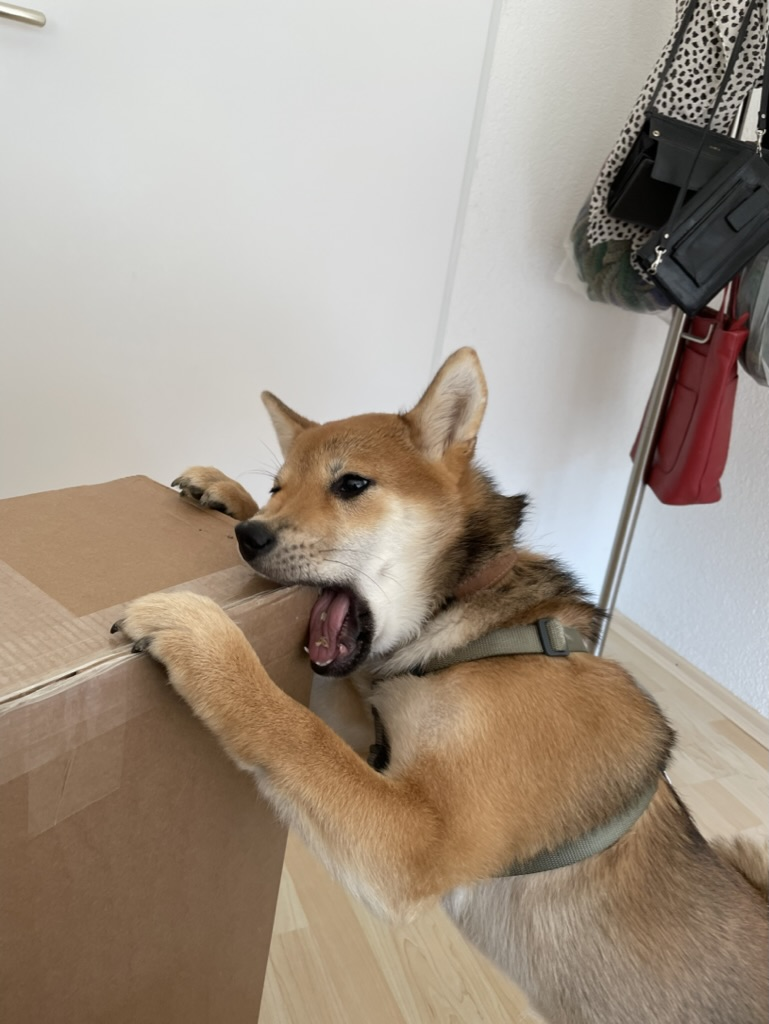

# Motivation: Why Move Beyond Feedforward Networks?

## Images as Data

[figure not shown]

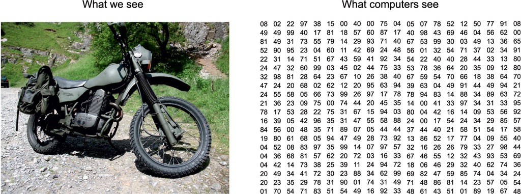

## What We Did with Feedforward Networks

- We trained a dense neural network on MNIST.
- Input: flattened 28x28 grayscale images → 784 features.
- Multiple fully connected layers.
- Achieved *reasonable* accuracy.

## What Is Wrong with That?

- Flattening destroys spatial structure:
  - The fact that pixel (5,5) is next to (5,6) is lost.
- Image is treated like a 1D vector, not the 2D shape that it is.

## A Matter of Scale

- For a 100x100 grayscale image:
  - 10,000 inputs → Huge weight matrix in first layer.
  - Computationally expensive.
- Even worse with RGB (3 channels).

## No Translational Invariance

- When the digit “3” appears in different parts of the image, the input values change.
- A feedforward network treats these as completely different patterns.
- It learns **position-specific features** rather than generalizing across positions.
- This limits its ability to recognize the same shape in different locations.

## Do We Need a Better Idea?

Absolutely! We want a model that

- Preserves spatial structure.
- Shares weights across locations.
- Is efficient with parameters.
- Can recognize features no matter where they occur.

## Enter Convolutional Neural Networks (CNNs)

# The Big Picture: What Is a CNN?

## What Makes CNNs Special?

- Think of CNNs like wearing *sunglasses with custom lenses*:
  - Each filter highlights specific features—e.g., detecting brightness, edges, or shadows.
  - Different filters reveal different “views” or **representations** of the same image.
- Inspired by the way the *visual cortex* processes images:
  - Neurons in the early visual system respond to specific orientations, edges, and textures.
  - CNNs mimic this by learning filters that activate for meaningful patterns.

## Local Receptive Fields

- Each neuron in a convolutional layer looks at a small part of the input.
- Filters scan the image — learning to detect edges, corners, textures.
- The same filter is applied at each location (weight sharing).
- Output: A map of where that pattern occurs $\Rightarrow$ **feature map**.

## From Pixels to Patterns

- CNNs do not just detect patterns—they build **hierarchies** of features.
- Early layers detect edges, corners, and textures.
- Middle layers combine edges into shapes, motifs, and strokes.
- Later layers recognize objects, digits, and categories.
- Each deeper layer has a larger receptive field and more abstract understanding.

## Adding Compression and Robustness

- After detecting patterns with convolution, we want to
  1. Reduce the size of the feature map $\rightarrow$ fewer computations.
  2. Summarize what has been detected in a region.
  3. Increase the robustness to small shifts and noise.
- We do this using **pooling** = downsampling the feature maps.
- We can think of this as retaining the most important signal from each region.

## The Layer Stack

```
graph TB
  Input[Input Image] --> Conv[Convolution]
  Conv --> ReLU[ReLU]
  ReLU --> Pool[Pooling]
  Pool -- flatten --> FC[Fully Connected]
  FC --> Output[Prediction]
```

- $\text{conv} \ \rightarrow \text{relu} \ \rightarrow \text{pool}$ is the feature extractor; this is often run multiple times with different architectures.
- The fully connected layers are the decision maker.
- Prior to running this, we turn 2D tensors into vectors through flattening.

# Preparing Images

## Normalization

- For computational purposes, pixel values should be converted to a standard range.
- Typically, this is $[0,1]$.
  - `ToTensor()` divides gray-scale pixel values by 255.
- Sometimes pixel values are standardized.
  - `transforms.Normalize()` is relevant here.

## Illustration

[figure not shown]

Under normalization, $F(12,13) = 1.000$, $F(18,9) = 0.745$, and $F(20,7) = 0.000$.

## Other Pre-Processing Steps

- Resizing.
- Centering/padding.
- Data augmentation.
- Channel reordering.

# The Convolution Operator

## What Is a Filter?

- A **filter** or kernel is a small matrix, e.g., $3 \times 3$ or $5 \times 5$.
- It is used to detect local patterns like edges or corners.
- Filters are applied across the image to generate feature maps.

## How Convolution Works

- The filter slides over the image (left to right, top to bottom).
- At each step, compute the element-wise product and sum $\rightarrow$ single number.
- Output: new image = feature map highlighting a specific pattern.

## How Convolution Works Cont’d

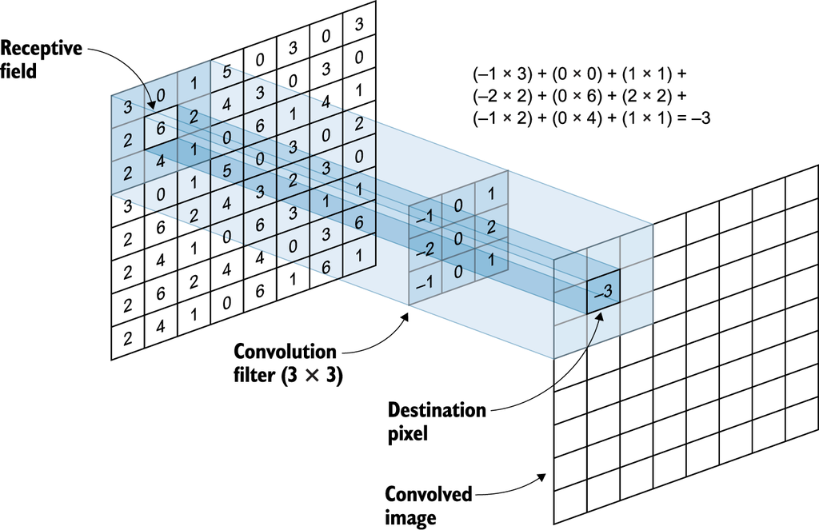

The values in the filter are weights.

## Parameter Sharing

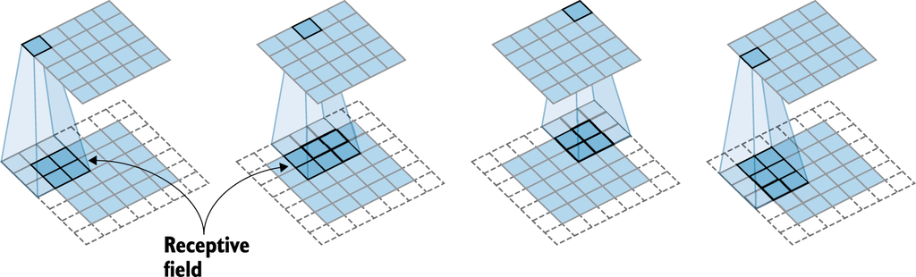

The same set of weights are used regardless of the focal pixel in the image. This parameter sharing makes training much more efficient.

## Filters Are Specialized

- Comment
- Example
- Exercise
- By setting the weights in a particular way, we can get the filter to focus on particular features.
- For instance a $3 \times 3$ vertical line detector would use

  $$\begin{bmatrix}
  -1 & 0 & 1 \\
  -2 & 0 & 2 \\
  -1 & 0 & 1
  \end{bmatrix}$$

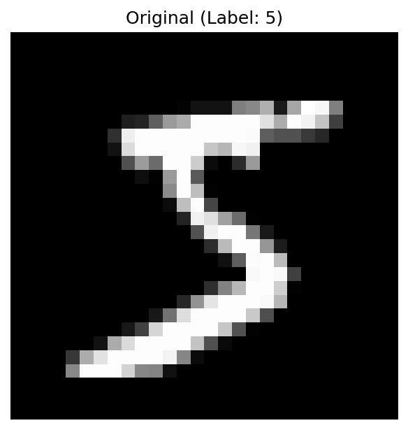

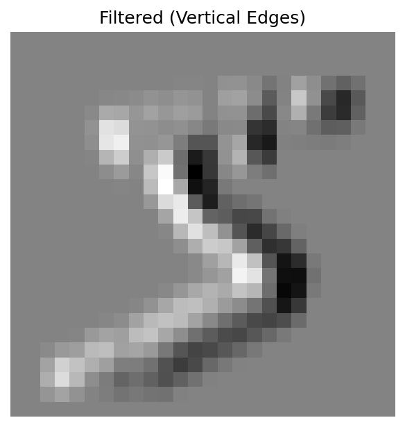

- Open *convo_exercise.ipynb*.
- Change the filter to

  $$\begin{bmatrix}
  -1 & -2 & -1 \\
  0 & 0 & 0 \\
  1 & 2 & 1
  \end{bmatrix}$$
- What happens?

## Another Illustration

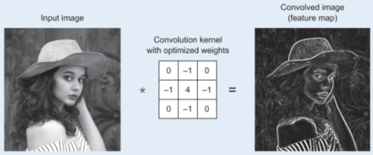

## Filter Stacks

- Because filters are specialized, we often stack them.
- We apply multiple filters in parallel to focus on different elements all at once.
- This results in multiple feature maps, each processing the image through a different “lens”.

## Filters Are Trained

- In CNNs, filters are **learned from data**, not hand-coded.
- Backpropagation adjusts the filter weights to detect useful patterns.
- Different filters specialize (e.g., vertical edges, curves).

## Comparison with Feedforward Networks

- For the MNIST example, a fully connected network with a hidden layer of 128 neurons would need
  - 128 bias terms
  - 128 $\times$ 784 = 100,352 weights
- A CNN using a 3 $\times$ 3 filter needs to learn
  - 1 bias
  - 3 $\times$ 3 = 9 weights
- Even in a stack of 32 filters, this is just 320 parameters.

# Padding, Striding, and Pooling

## Why Do We Pool?

- After convolution, feature maps can still be high-resolution.
- Pooling reduces spatial size:
  - Down-samples the feature map.
  - Keeps important features, while dropping unimportant variation.
- Helps make the network more robust to slight shifts.

## Max Pooling Intuition

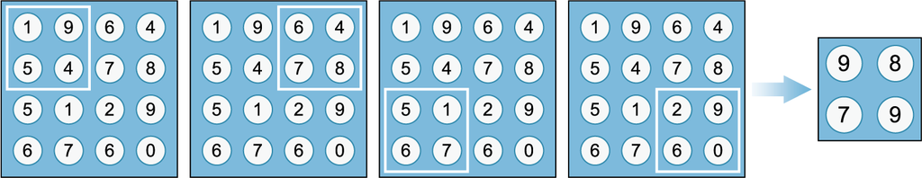

- A pooling window slides across the feature map.
- It takes the *maximum* value ion each patch.
- Thus, it keeps the strongest activations, resulting in a sharper, cleaner map.

## How Effective is Max Pooling?

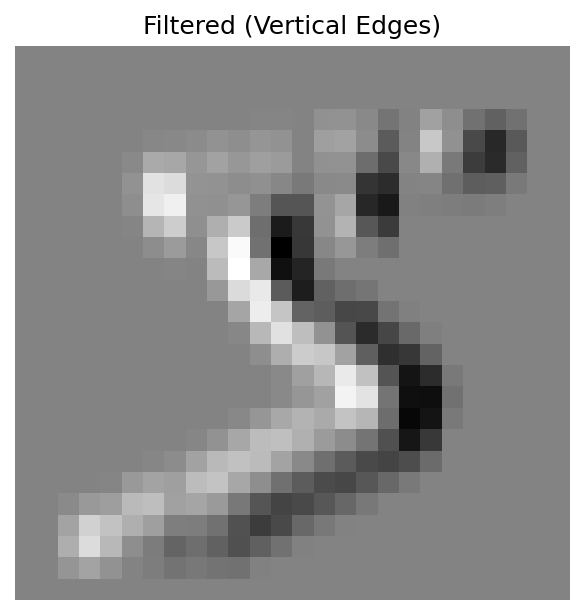

26 X 26 Resolution

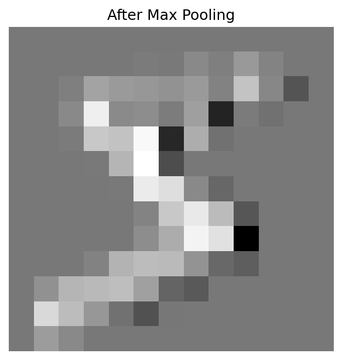

13 X 13 Resolution

## Max Versus Average Pooling

| Aspect | Max Pooling | Average Pooling |
| --- | --- | --- |
| Operation | Takes the maximum | Takes the mean |
| Effect | Keeps strongest activation | Preserves overall structure |
| Sparsity | Increases sparsity | Retains more low-level information |
| Robustness | More robust to noise | Smoother but may blur details |
| Typical Use | Default in most CNNs | Used in early CNNs and for specific tasks |
| Interpretability | Highlights key features | Keeps all signals (weaker + stronger) |

## Pooling Details

- Common pool size is $2 \times 2$.
- No learnable weights—fixed functions.
- Often follows a ReLU activation.

## Pooling Parameters

- **Stride** = the number of pixels the filter moves (or “slides”) across the input image at each step during convolution or pooling.
- In our example, we set stride to 2. We can play around with that.

## Padding

- **Padding** = adding extra pixels (usually zeros) around the border of the input image or feature map to control the size of the output after applying a convolution.
- We add padding because the outer pixels lack neighbors.
  - Since the convolution filter must fit entirely within the image, we lose the outer pixels.
- Padding adds 0 on the outside of the image.

## Computational Formulas

**Convolutional Output**

$$\begin{align}
W_{\text{out}} &= \left \lfloor \frac{W_{\text{in}} - K + 2P}{S} \right \rfloor + 1 \\
H_{\text{out}} &= \left \lfloor \frac{H_{\text{in}} - K + 2P}{S} \right \rfloor + 1
\end{align}$$

**Pooling Output**

$$\begin{align}
W_{\text{out}} &= \left \lfloor \frac{W_{\text{in}} - K}{S} \right \rfloor + 1 \\
H_{\text{out}} &= \left \lfloor \frac{H_{\text{in}} - K}{S} \right \rfloor + 1
\end{align}$$

## Examples

- A
- B
- Input is $28 \times 28$, no padding, $3 \times 3$ kernel, stride = 1, $2 \times 2$ pooling filter, stride =2.
- Convolutional output:

  $$W_{\text{out}} = H_{\text{out}} = \left \lfloor \frac{28 - 3 + 2 \times 0}{1} \right \rfloor + 1 = 26$$
- Max pooling output:

  $$W_{\text{out}} = H_{\text{out}} = \left \lfloor \frac{26 - 2}{2} \right \rfloor + 1 = 13$$
- Input is $28 \times 28$, padding = 1, $3 \times 3$ kernel, stride = 1, $2 \times 2$ pooling filter, stride =2.
- Convolutional output:

  $$W_{\text{out}} = H_{\text{out}} = \left \lfloor \frac{28 - 3 + 2 \times 1}{1} \right \rfloor + 1 = 28$$
- Max pooling output:

  $$W_{\text{out}} = H_{\text{out}} = \left \lfloor \frac{28 - 2}{2} \right \rfloor + 1 = 14$$

## Exercise

$\Rightarrow$ Play around with the code in the code on OLAT.

# A CNN for MNIST

## Some Basic Decisions

- CNN architectures are often progressive.
- We start with few filters (**channels**) and then increase the number in subsequent layers.
- Since pooling reduces spatial resolution, we can afford to have more channels in later layers.
- These can detect more complex shapes and motifs by combining patterns that were detected before.

## Sample Architecture

| Layer | Filters | Output Size |
| --- | --- | --- |
| Conv1+ReLU | 12 | $28 \times 28 \rightarrow 26 \times 26$ |
| Max Pool $2 \times 2$ | 12 | $26 \times 26 \rightarrow 13 \times 13$ |
| Conv2+ReLU | 36 | $13 \times 13 \rightarrow 11 \times 11$ |
| Max Pool $2 \times 2$ | 36 | $11 \times 11 \rightarrow 5 \times 5$ |
| Flatten | NA | $36 \times 5 \times 5 = 900$ |
| Fully Connected | e.g., 128 |  |
| Output Layer | 10 |  |

## Let’s Try This Out

$\Rightarrow$ Let’s run some Python code. You can play around with some of the settings to see their effects. You could also add even more layers.

# Preventing Over-Fits

## What is Over-Fitting Again?

- The model performs well on training data but poorly on new, unseen data.
- It memorizes noise instead of learning general patterns.
- Common when models have high capacity and training data is limited.

## Strategies to Prevent Over-Fits

- **Dropout**: randomly deactivate neurons during training.
- **Weight Decay**: penalize large weights (L2 regularization).
- **Data Augmentation**: generate new training examples from existing ones, making memorization more difficult.

## Refresher on Dropout and Weight Decay

- Dropout: `self.dropout = nn.Dropout(p=0.25)` followed by `x = self.dropout(x)`.
- Weight decay: `optimizer = torch.optim(Adam(model.parameters(), lr=0.001, weight_decay=1e-4)`.

## What Is Data Augmentation?

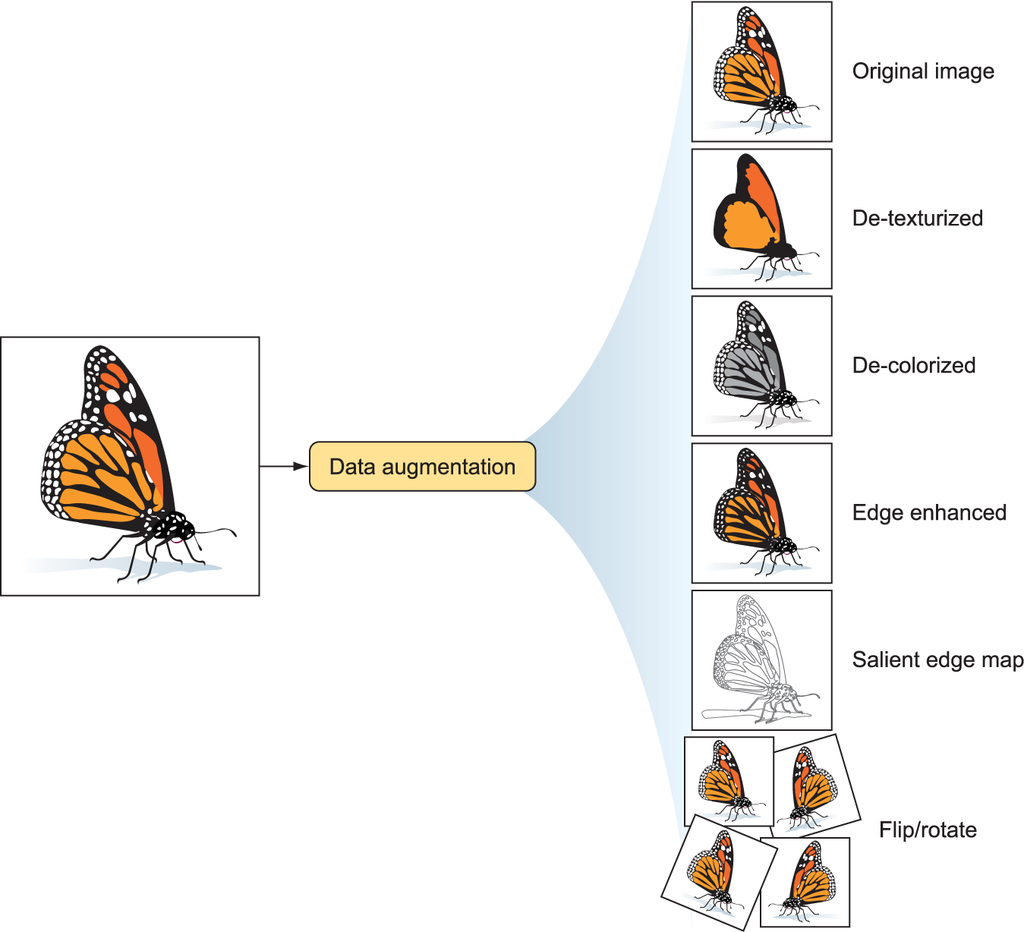

**Data augmentation** = the process of creating new training examples by slightly modifying existing data, helping the model learn more general and robust patterns.

## Python Augmentation Code

- Augmentation requires `torchvision.transforms`.
- Geometric augmentations include horizontal and vertical flips, random rotations, distortions, and cropping.
- Color augmentations include grayscale conversions, changes in brightness through jittering, Gaussian blurs, contrast, and sharpness adjustments.

## Some Examples

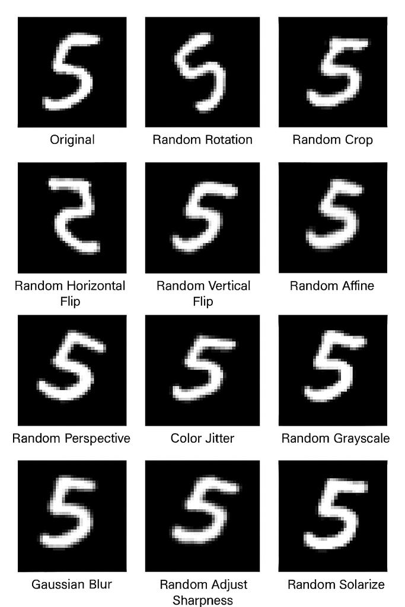

## Let’s See This in Action

$\Rightarrow$ Let’s add data augmentation to our code. Feel free to play around with different transformations.

## References

Lecun, Yann, Léon Bottou, Yoshua Bengio, and Patrick Haffner. 1998. “Gradient-Based Learning Applied to Document Recognition.” *Proceedings of the IEEE* 86 (11): 2278–2324. https://doi.org/10.1109/5.726791.